# Primary Analyses

Kendra Wyant

2021-06-13

Purpose: This file contains the following primary analyses along with supporting figures

- One-way ANOVA to assess effort on willingness to continue using signals
- Correlation matrix for each self-report measure with signal means and SDs
- ICC to assess consistency in ratings across signals for each self-report measure

### Setup

Paths

```r
path_burden <- "/Volumes/private/studydata/risk/data_processed/burden"
```

Packages and Source

```r
library(tidyverse)
library(kableExtra)
library(lme4)
library(ggtext)
library(car)
library(corx)
library(patchwork)
library(psych)

options(knitr.kable.NA = '')
```

### Read in data

```r
burden <- read_csv(file.path(path_burden, "burden.csv"), col_types = cols()) %>%
  # wristband will be analyzed in supplemental - not enough observations
  select(-contains("wristband"))
  # daily survey (x1) will only be included in supplemental also
```

Pull out last observation for each participant

```r
# pull out last available sleep monitor data since this date will be earlier than last survey date for some
burden_sleep <- burden %>%
  filter(!is.na(sleep_interfere)) %>%
  group_by(subid) %>%
  arrange(desc(date)) %>%
  slice(1) %>%
  ungroup() %>%
  select(c(subid, starts_with("sleep_")))

# pull out most recent survey for each subid
burden_last <- burden %>%
  select(-c(starts_with("sleep_"))) %>%
  group_by(subid) %>%
  arrange(desc(date)) %>%
  slice(1) %>%
  ungroup() %>%
  # join with sleep data
  full_join(burden_sleep, by = c("subid")) %>%
  glimpse()
```

```
## Rows: 154
## Columns: 28
## $ subid                    <dbl> 1, 2, 3, 5, 6, 7, 9, 10, 11, 15, 16, 18, 19,…
## $ response_id              <chr> "R_3pb42s0hzoIFsk9", "R_1rvLRa6XSAGssBO", "R…
## $ date                     <date> 2017-06-05, 2017-06-16, 2017-06-21, 2017-09…
## $ daily_survey_interfere   <dbl> 1, 1, 1, 1, 1, 2, 0, 2, 2, 1, 1, 1, 1, 1, 1,…
## $ daily_survey_dislike     <dbl> 1, 1, 2, 1, 1, 2, 1, 2, 0, 1, 1, 1, 0, 2, -1…
## $ daily_survey_4_1year     <dbl> 1, -2, 2, 1, 1, 2, -1, 2, -1, 1, -1, 1, 0, -…
## $ daily_survey_1_1year     <dbl> 1, -2, 2, 1, 2, 2, 0, 2, -2, 1, 1, 2, 2, 2, …
## $ daily_survey_text        <chr> "The home surveys were easy to complete but …
## $ audio_checkin_interfere  <dbl> 1, 2, 1, 1, 1, 2, 1, 2, 2, -1, 1, -2, -1, 2,…
## $ audio_checkin_dislike    <dbl> 1, 2, 2, 1, 1, 2, 1, 2, 0, -1, 1, -2, -2, 2,…
## $ audio_checkin_1year      <dbl> 1, 2, 2, 1, 1, 2, 1, 2, -2, -1, 1, -2, -2, 2…
## $ audio_checkin_text       <chr> "I enjoyed the daily check more than all the…
## $ carrying_phone_interfere <dbl> 1, 2, 2, 2, 2, 2, 1, 2, 2, 2, 2, 2, 2, 2, 1,…
## $ carrying_phone_dislike   <dbl> 1, 2, 2, 2, 2, 2, 1, 2, 2, 2, 2, 2, 2, 2, 1,…
## $ carrying_phone_1year     <dbl> 1, 2, 2, 2, 2, 2, 1, 2, -2, 2, 2, 2, 2, 2, -…
## $ carrying_phone_text      <chr> "The i-phone is a great resource to use. Hop…
## $ location_dislike         <dbl> 1, 1, 2, -1, 1, 2, 1, 2, 1, 1, 1, 0, 2, 2, 1…
## $ location_1year           <dbl> 1, 2, 2, 1, 2, 2, 0, 2, -2, 1, 1, -1, 2, 2, …
## $ location_text            <chr> "Not an issue.", "This didn't change where I…
## $ sms_content_dislike      <dbl> 1, 1, 2, -1, 1, 2, 0, 2, 0, 1, -1, -2, 2, 2,…
## $ sms_content_1year        <dbl> 1, 2, 1, 1, 2, 2, 0, 2, -2, 1, -1, 0, 1, 2, …
## $ phone_text               <chr> "I did not use the texting options and prefe…
## $ all_logs_dislike         <dbl> 0, 1, 2, 1, 1, 2, 0, 2, 0, 1, 0, 0, 2, 2, 1,…
## $ all_logs_1year           <dbl> 1, 2, 1, 1, 2, 2, 0, 2, -2, 1, 0, 1, 2, 2, -…
## $ sleep_interfere          <dbl> 1, 2, 2, 1, 1, 2, -2, 2, 0, 2, 2, 2, 2, 2, 1…
## $ sleep_dislike            <dbl> 1, 2, 2, 1, -1, 2, 2, 2, -1, 2, 1, 2, 2, 2, …
## $ sleep_1year              <dbl> 1, -2, 2, 1, 1, 2, -1, 2, -2, -2, 1, 2, 2, 2…
## $ sleep_text               <chr> "There were problems with the sleep monitor …
```

### Analysis of Effort on Willingness to Use and Dislike

#### Create dataframes

- active = audio check in and daily survey
- passive = location, sms content, logs

NOTE: Sleep monitor is an active measure but due to sample size is not included in analyses. Carrying phone is not included as personal sensing signal. Daily survey (x 1) is hypothetical and only included in supplemental.  
Means and differences

```r
burden_dislike <- burden_last %>%
  # get subject level means for active and passive measures
  group_by(subid) %>%
  summarise(Active = mean(c(daily_survey_dislike, audio_checkin_dislike), na.rm = TRUE),
            Passive = mean(c(location_dislike, all_logs_dislike, sms_content_dislike), na.rm = TRUE),
            dislike_diff = Passive - Active)
burden_dislike %>%
  print(n = Inf)
```

```
## # A tibble: 154 x 4
##     subid Active Passive dislike_diff
##   * <dbl>  <dbl>   <dbl>        <dbl>
##   1     1    1     0.667       -0.333
##   2     2    1.5   1           -0.5
##   3     3    2     2            0
##   4     5    1    -0.333       -1.33
##   5     6    1     1            0
##   6     7    2     2            0
##   7     9    1     0.333       -0.667
##   8    10    2     2            0
##   9    11    0     0.333        0.333
##  10    15    0     1            1
##  11    16    1     0           -1
##  12    18   -0.5  -0.667       -0.167
```

[output cut: 142 more lines]

```r
burden_willingness <- burden_last %>%
  # get subject level means for active and passive measures
  group_by(subid) %>%
  summarise(Active = mean(c(daily_survey_4_1year, audio_checkin_1year), na.rm = TRUE),
            Passive = mean(c(location_1year, all_logs_1year, sms_content_1year), na.rm = TRUE),
            willingness_diff = Passive - Active)
burden_willingness %>%
  print(n = Inf)
```

```
## # A tibble: 154 x 4
##     subid Active Passive willingness_diff
##   * <dbl>  <dbl>   <dbl>            <dbl>
##   1     1    1     1                0
##   2     2    0     2                2
##   3     3    2     1.33            -0.667
##   4     5    1     1                0
##   5     6    1     2                1
##   6     7    2     2                0
##   7     9    0     0                0
##   8    10    2     2                0
##   9    11   -1.5  -2               -0.5
##  10    15    0     1                1
##  11    16    0     0                0
##  12    18   -0.5   0                0.5
```

[output cut: 142 more lines]

#### ANOVA

**Dislike**

```r
m_dislike <- lm(dislike_diff ~ 1, data = burden_dislike)
summary(m_dislike)
```

```
##
## Call:
## lm(formula = dislike_diff ~ 1, data = burden_dislike)
##
## Residuals:
##     Min      1Q  Median      3Q     Max
## -4.1028 -0.4361 -0.1028  0.5639  2.8972
##
## Coefficients:
##             Estimate Std. Error t value Pr(>|t|)
## (Intercept)  0.10281    0.08503   1.209    0.228
##
## Residual standard error: 1.055 on 153 degrees of freedom
```

```r
Anova(m_dislike, type = 3, test = "F")
```

```
## Anova Table (Type III tests)
##
## Response: dislike_diff
##              Sum Sq  Df F value Pr(>F)
## (Intercept)   1.628   1  1.4621 0.2285
## Residuals   170.344 153
```

**Willingness**

```r
m_willingness <- lm(willingness_diff ~ 1, data = burden_willingness)
summary(m_willingness)
```

```
##
## Call:
## lm(formula = willingness_diff ~ 1, data = burden_willingness)
##
## Residuals:
##     Min      1Q  Median      3Q     Max
## -2.3214 -0.3214 -0.1548  0.3452  3.3452
##
## Coefficients:
##             Estimate Std. Error t value Pr(>|t|)
## (Intercept)  0.15476    0.07292   2.122   0.0354 *
## ---
## Signif. codes:  0 '***' 0.001 '**' 0.01 '*' 0.05 '.' 0.1 ' ' 1
##
## Residual standard error: 0.9049 on 153 degrees of freedom
```

```r
Anova(m_willingness, type = 3, test = "F")
```

```
## Anova Table (Type III tests)
##
## Response: willingness_diff
##              Sum Sq  Df F value  Pr(>F)
## (Intercept)   3.688   1  4.5045 0.03542 *
## Residuals   125.284 153
## ---
## Signif. codes:  0 '***' 0.001 '**' 0.01 '*' 0.05 '.' 0.1 ' ' 1
```

Long format confirms exact same values  
Willingness

```r
burden_willingness_long <- burden_willingness %>%
  pivot_longer(cols = c(Active, Passive), names_to = "effort", values_to = "willingness")

# don't need random effects for effort since only one observation per level
m_willingness_long <- lmer(willingness ~ effort + (1 | subid), data = burden_willingness_long)
summary(m_willingness_long)
```

```
## Linear mixed model fit by REML ['lmerMod']
## Formula: willingness ~ effort + (1 | subid)
##    Data: burden_willingness_long
##
## REML criterion at convergence: 825
##
## Scaled residuals:
##      Min       1Q   Median       3Q      Max
## -2.80446 -0.40427  0.09722  0.53835  2.42359
##
## Random effects:
##  Groups   Name        Variance Std.Dev.
##  subid    (Intercept) 0.6562   0.8101
##  Residual             0.4094   0.6399
## Number of obs: 308, groups:  subid, 154
##
## Fixed effects:
##               Estimate Std. Error t value
## (Intercept)    0.68506    0.08318   8.236
## effortPassive  0.15476    0.07292   2.122
##
## Correlation of Fixed Effects:
##             (Intr)
## effortPassv -0.438
```

```r
Anova(m_willingness_long, type = 3, test = "F")
```

```
## Analysis of Deviance Table (Type III Wald F tests with Kenward-Roger df)
##
## Response: willingness
##                   F Df Df.res    Pr(>F)
## (Intercept) 67.8236  1 221.87 1.537e-14 ***
## effort       4.5045  1 153.00   0.03542 *
## ---
## Signif. codes:  0 '***' 0.001 '**' 0.01 '*' 0.05 '.' 0.1 ' ' 1
```

Dislike

```r
burden_dislike_long <- burden_dislike %>%
  pivot_longer(cols = c(Active, Passive), names_to = "effort", values_to = "dislike")

m_dislike_long <- lmer(dislike ~ effort + (1 | subid), data = burden_dislike_long)
summary(m_dislike_long)
```

```
## Linear mixed model fit by REML ['lmerMod']
## Formula: dislike ~ effort + (1 | subid)
##    Data: burden_dislike_long
##
## REML criterion at convergence: 819.3
##
## Scaled residuals:
##     Min      1Q  Median      3Q     Max
## -3.2276 -0.5471  0.0808  0.6760  2.2713
##
## Random effects:
##  Groups   Name        Variance Std.Dev.
##  subid    (Intercept) 0.3317   0.5759
##  Residual             0.5567   0.7461
## Number of obs: 308, groups:  subid, 154
##
## Fixed effects:
##               Estimate Std. Error t value
## (Intercept)    0.73052    0.07595   9.618
## effortPassive  0.10281    0.08503   1.209
##
## Correlation of Fixed Effects:
##             (Intr)
## effortPassv -0.560
```

```r
Anova(m_dislike_long, type = 3, test = "F")
```

```
## Analysis of Deviance Table (Type III Wald F tests with Kenward-Roger df)
##
## Response: dislike
##                   F Df Df.res Pr(>F)
## (Intercept) 92.5093  1 268.56 <2e-16 ***
## effort       1.4621  1 153.00 0.2285
## ---
## Signif. codes:  0 '***' 0.001 '**' 0.01 '*' 0.05 '.' 0.1 ' ' 1
```

#### Bar plots

Dislike

```r
m_graph <- lm(dislike ~ effort, data = burden_dislike_long)

d_graph <- expand.grid(effort = c("Active", "Passive"))
d_graph <- lmSupport::modelPredictions(m_graph, d_graph)

dislike_anova <- d_graph %>%
  mutate(measure = "Dislike") %>%
  ggplot(aes(x = effort, y = Predicted, fill = effort)) +
  geom_bar(stat = "identity", color = "black") +
  geom_errorbar(aes(ymax = CIHi, ymin = CILo), width = .25) +
  labs(x = NULL,
       y = NULL) +
  facet_wrap(~ measure) +
  theme_classic() +
  theme(text = element_text(family = "Arial", size = 12),
        legend.position = "none",
        legend.background = element_blank()) +
  scale_fill_manual(values = c("#FFDEDE", "#DBF8FF")) +
  scale_y_continuous(breaks = c(-2, -1, 0, 1, 2), labels = c("Strongly agree", "Agree", "Undecided", "Disagree", "Strongly disagree"), limits = c(-2, 2)) +
  geom_hline(yintercept = 0, linetype = "dashed", size = .4, color = "#444242")
```

Willingness

```r
m_graph_2 <- lm(willingness ~ effort, data = burden_willingness_long)

d_graph_2 <- expand.grid(effort = c("Active", "Passive"))
d_graph_2 <- lmSupport::modelPredictions(m_graph_2, d_graph_2)

willingness_anova <- d_graph_2 %>%
  mutate(measure = "Willingness to Continue") %>%
  ggplot(aes(x = effort, y = Predicted, fill = effort)) +
  geom_bar(stat = "identity", color = "black") +
  geom_errorbar(aes(ymax = CIHi, ymin = CILo), width = .25) +
  labs(x = NULL,
       y = NULL) +
  facet_wrap(~ measure) +
  theme_classic() +
  theme(text = element_text(family = "Arial", size = 12),
        legend.position = "none",
        legend.background = element_blank()) +
  scale_fill_manual(values = c("#FFDEDE", "#DBF8FF")) +
  scale_y_continuous(breaks = c(-2, -1, 0, 1, 2), position = "right", labels = c("Strongly disagree", "Disagree", "Undecided", "Agree", "Strongly agree"), limits = c(-2, 2)) +
  geom_hline(yintercept = 0, linetype = "dashed", size = .4, color = "#444242") +
  ggsignif::geom_signif(comparisons = list(c("Active", "Passive")),
              annotations = "*")
```

Save figures

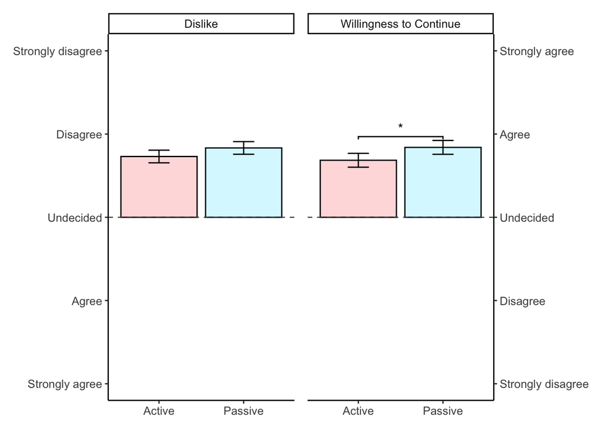

```r
final_anova <- wrap_plots(dislike_anova, willingness_anova, ncol = 2)
final_anova
```

```r
# ggsave(plot = final_anova,  "~/Desktop/anova.png", width = 8.5, height = 4, units = "in", device = "png",  dpi = 500)
```

#### Histogram of averages

**Dislike**

```r
# already have participant averages for active/passive
burden_dislike_long %>%
  select(-dislike_diff) %>%
  glimpse()
```

```
## Rows: 308
## Columns: 3
## $ subid   <dbl> 1, 1, 2, 2, 3, 3, 5, 5, 6, 6, 7, 7, 9, 9, 10, 10, 11, 11, 15,…
## $ effort  <chr> "Active", "Passive", "Active", "Passive", "Active", "Passive"…
## $ dislike <dbl> 1.0000000, 0.6666667, 1.5000000, 1.0000000, 2.0000000, 2.0000…
```

```r
dislike_avg_hist <- burden_dislike_long %>%
  # bin continuous means, keep numeric
  mutate(dislike_binned = as.numeric(cut(dislike, breaks = c(-2.5, -1.5, -0.5, 0.5, 1.5, 2.5)))) %>%
  # change 1 to 5 scale to -2 to 2
  mutate(dislike_binned = dislike_binned - 3) %>%
  ggplot(aes(x = dislike_binned, y = ..prop.., group = effort, fill = effort)) +
  geom_bar(color = "black") +
  facet_wrap(~ effort, ncol = 1) +
  theme_classic() +
  labs(y = "Proportion",
       x = NULL) +
    theme(legend.position = "none",
        text = element_text(family = "Arial", size = 12),
        axis.text.x = element_text(angle = 45, hjust = 1)) +
  ylim(0, .6) +
  scale_x_continuous(breaks = c(-2, -1, 0, 1, 2),
                   labels = c("Strongly agree", "Agree", "Undecided", "Disagree", "Strongly disagree")) +
  scale_fill_manual(values = c("#FFDEDE", "#DBF8FF")) +
  geom_vline(aes(xintercept = m), burden_dislike_long %>%
               group_by(effort) %>%
               summarise(m = mean(dislike)), size = .4) +
  geom_vline(aes(xintercept = 0), linetype = "dashed", size = .4, color = "#787575")
```

**Willingness**

```r
# already have participant averages for active/passive
burden_willingness_long %>%
  select(-willingness_diff) %>%
  glimpse()
```

```
## Rows: 308
## Columns: 3
## $ subid       <dbl> 1, 1, 2, 2, 3, 3, 5, 5, 6, 6, 7, 7, 9, 9, 10, 10, 11, 11,…
## $ effort      <chr> "Active", "Passive", "Active", "Passive", "Active", "Pass…
## $ willingness <dbl> 1.000000, 1.000000, 0.000000, 2.000000, 2.000000, 1.33333…
```

```r
willingness_avg_hist <- burden_willingness_long %>%
  # bin continuous means, keep numeric
  mutate(willingness_binned = as.numeric(cut(willingness, breaks = c(-2.5, -1.5, -0.5, 0.5, 1.5, 2.5)))) %>%
  # change 1 to 5 scale to -2 to 2
  mutate(willingness_binned = willingness_binned - 3) %>%
  ggplot(aes(x = willingness_binned, y = ..prop.., group = effort, fill = effort)) +
  geom_bar(color = "black") +
  facet_wrap(~ effort, ncol = 1) +
  theme_classic() +
  labs(y = "Proportion",
       x = NULL) +
    theme(legend.position = "none",
        text = element_text(family = "Arial", size = 12),
        axis.text.x = element_text(angle = 45, hjust = 1)) +
  ylim(0, .6) +
  scale_x_continuous(breaks = c(-2, -1, 0, 1, 2),
                   labels = c("Strongly disagree", "Disgree", "Undecided", "Agree", "Strongly agree")) +
  scale_fill_manual(values = c("#FFDEDE", "#DBF8FF")) +
  geom_vline(aes(xintercept = m), burden_willingness_long %>%
               group_by(effort) %>%
               summarise(m = mean(willingness)), size = .4) +
  geom_vline(aes(xintercept = 0), linetype = "dashed", size = .4, color = "#787575")
```

Save figures

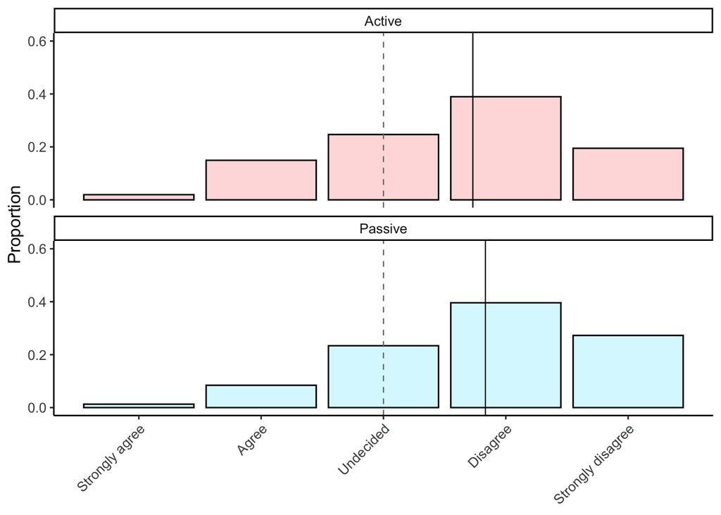

```r
dislike_avg_hist
```

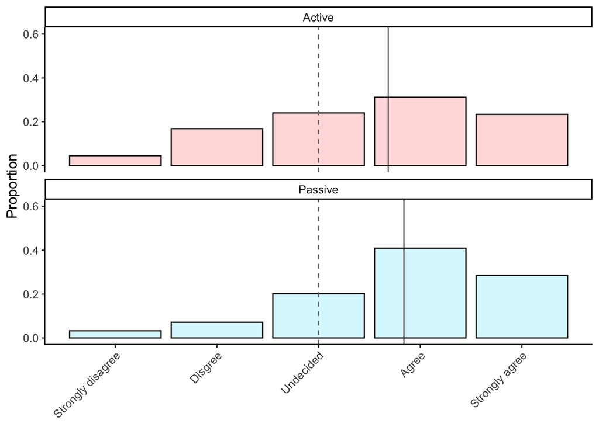

```r
willingness_avg_hist
```

```r
# ggsave(plot = dislike_avg_hist,  "~/Desktop/dislike_anova_hist.png", width = 5, height = 5.5, units = "in", device = "png",  dpi = 500)
# ggsave(plot = willingness_avg_hist,  "~/Desktop/willingness_anova_hist.png", width = 5, height = 5.5, units = "in", device = "png",  dpi = 500)
```

### Self Report Acceptability

```r
# run regressions (one sample t-tests) for each measure and item
int_sl <- broom::tidy(lm(sleep_interfere ~ 1, data = burden_last)) %>%
  mutate(sd = sd(burden_last$sleep_interfere, na.rm = TRUE),
         d = mean(burden_last$sleep_interfere, na.rm = TRUE)/sd)
int_a <-  broom::tidy(lm(audio_checkin_interfere ~ 1, data = burden_last)) %>%
  mutate(sd = sd(burden_last$audio_checkin_interfere, na.rm = TRUE),
         d = mean(burden_last$audio_checkin_interfere, na.rm = TRUE)/sd)
int_s4 <-  broom::tidy(lm(daily_survey_interfere ~ 1, data = burden_last)) %>%
  mutate(sd = sd(burden_last$daily_survey_interfere, na.rm = TRUE),
         d = mean(burden_last$daily_survey_interfere, na.rm = TRUE)/sd)
dis_sl <-  broom::tidy(lm(sleep_dislike ~ 1, data = burden_last)) %>%
  mutate(sd = sd(burden_last$sleep_dislike, na.rm = TRUE),
         d = mean(burden_last$sleep_dislike, na.rm = TRUE)/sd)
dis_a <-  broom::tidy(lm(audio_checkin_dislike ~ 1, data = burden_last)) %>%
  mutate(sd = sd(burden_last$audio_checkin_dislike, na.rm = TRUE),
         d = mean(burden_last$audio_checkin_dislike, na.rm = TRUE)/sd)
dis_s4 <-  broom::tidy(lm(daily_survey_dislike ~ 1, data = burden_last)) %>%
  mutate(sd = sd(burden_last$daily_survey_dislike, na.rm = TRUE),
         d = mean(burden_last$daily_survey_dislike, na.rm = TRUE)/sd)
dis_loc <-  broom::tidy(lm(location_dislike ~ 1, data = burden_last)) %>%
  mutate(sd = sd(burden_last$location_dislike, na.rm = TRUE),
         d = mean(burden_last$location_dislike, na.rm = TRUE)/sd)
dis_log <-  broom::tidy(lm(all_logs_dislike ~ 1, data = burden_last)) %>%
  mutate(sd = sd(burden_last$all_logs_dislike, na.rm = TRUE),
         d = mean(burden_last$all_logs_dislike, na.rm = TRUE)/sd)
dis_sms <-  broom::tidy(lm(sms_content_dislike ~ 1, data = burden_last)) %>%
  mutate(sd = sd(burden_last$sms_content_dislike, na.rm = TRUE),
         d = mean(burden_last$sms_content_dislike, na.rm = TRUE)/sd)
use_a <-  broom::tidy(lm(audio_checkin_1year ~ 1, data = burden_last)) %>%
  mutate(sd = sd(burden_last$audio_checkin_1year, na.rm = TRUE),
         d = mean(burden_last$audio_checkin_1year, na.rm = TRUE)/sd)
use_sl <-  broom::tidy(lm(sleep_1year ~ 1, data = burden_last)) %>%
  mutate(sd = sd(burden_last$sleep_1year, na.rm = TRUE),
         d = mean(burden_last$sleep_1year, na.rm = TRUE)/sd)
use_s4 <-  broom::tidy(lm(daily_survey_4_1year ~ 1, data = burden_last)) %>%
  mutate(sd = sd(burden_last$daily_survey_4_1year, na.rm = TRUE),
         d = mean(burden_last$daily_survey_4_1year, na.rm = TRUE)/sd)
use_s1 <-  broom::tidy(lm(daily_survey_1_1year ~ 1, data = burden_last)) %>%
  mutate(sd = sd(burden_last$daily_survey_1_1year, na.rm = TRUE),
         d = mean(burden_last$daily_survey_1_1year, na.rm = TRUE)/sd)
use_loc <-  broom::tidy(lm(location_1year ~ 1, data = burden_last)) %>%
  mutate(sd = sd(burden_last$location_1year, na.rm = TRUE),
         d = mean(burden_last$location_1year, na.rm = TRUE)/sd)
use_log <-  broom::tidy(lm(all_logs_1year ~ 1, data = burden_last)) %>%
  mutate(sd = sd(burden_last$all_logs_1year, na.rm = TRUE),
         d = mean(burden_last$all_logs_1year, na.rm = TRUE)/sd)
use_sms <-  broom::tidy(lm(sms_content_1year ~ 1, data = burden_last)) %>%
  mutate(sd = sd(burden_last$sms_content_1year, na.rm = TRUE),
         d = mean(burden_last$sms_content_1year, na.rm = TRUE)/sd)
```

#### Interference

*Going to remove stars and bold significant values in word version.*

```r
corrplot_int <- burden_last %>%
  select(`Audio Check-in` = audio_checkin_interfere,
         `EMA` = daily_survey_interfere,
         `Sleep Monitoring` = sleep_interfere) %>%
  corx(triangle = "lower",
       stars = c(0.05),
       method = "pearson",
       describe = c(`$M$` = mean, `$SD$` = sd))

corrplot_int <- as_tibble(corrplot_int, rownames = " ")
corrplot_int[corrplot_int == " - " ] <- "--"

corrplot_int <- corrplot_int %>%
  mutate(`$N$` = c(154, 154, 87)) %>%
  mutate(`$t$` = c(str_c(round(int_a$statistic, 2), "*"),
                   str_c(round(int_s4$statistic, 2), "*"),
                   str_c(round(int_sl$statistic, 2), "*"))) %>%
  mutate(`$d$` = (c(round(int_a$d, 2), round(int_s4$d, 2), round(int_sl$d, 2)))) %>%
  select(` `, `1`, `2`, `$N$`, `$M$`, `$SD$`, everything())

corrplot_int %>%
  kbl(align = c("l", "c", "c", "c", "c", "c", "c", "c")) %>%
  kable_classic(html_font = "Arial") %>%
  row_spec(c(1:3), background = "#FFDEDE") %>%
  pack_rows("Active", 1, 3, background = "#FFDEDE") %>%
  footnote("* p < 0.05")
```

1

2

$N$

$M$

$SD$

$t$

$d$

**Active**

1. Audio Check-in

–

154

0.78

1.07

9.05*

0.73

2. EMA

.42*

–

154

0.91

0.99

11.37*

0.92

3. Sleep Monitoring

-.06

.24*

87

1.38

0.87

14.86*

1.59

Note:

* p < 0.05

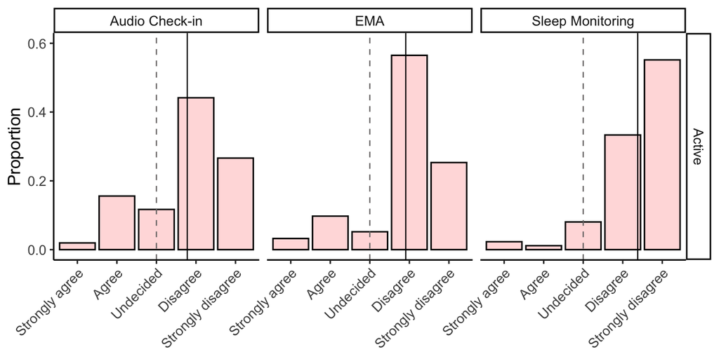

```r
burden_plot_int <- burden_last %>%
  select(contains("interfere")) %>%
  pivot_longer(everything(), "measure", values_drop_na = TRUE) %>%
  mutate(measure = factor(measure,
                          levels = c("audio_checkin_interfere", "daily_survey_interfere",
                                     "sleep_interfere", "carrying_phone_interfere"),
                          labels = c("Audio Check-in", "EMA", "Sleep Monitoring", "Carrying Phone"))) %>%
  mutate(value = factor(value, levels = c(-2:2), labels = c("Strongly agree", "Agree", "Undecided", "Disagree", "Strongly disagree"))) %>%
  mutate(active = case_when(measure == "Audio Check-in" ~ "Active",
                            measure == "EMA" ~ "Active",
                            measure == "Sleep Monitoring" ~ "Active"))

active <- burden_plot_int %>%
  filter(measure == "Audio Check-in" | measure == "EMA" | measure == "Sleep Monitoring") %>%
  ggplot(aes(x = value, y = ..prop.., group = measure)) +
  geom_bar(color = "black", fill = "#FFDEDE") +
  facet_grid(active ~ measure) +
  theme_classic() +
  labs(y = "Proportion",
       x = NULL) +
  theme(legend.position = "none",
        text = element_text(family = "Arial", size = 12),
        axis.text.x = element_text(angle = 45, hjust = 1)) +
  ylim(0, .6) +
  geom_vline(aes(xintercept = "Undecided"), linetype = "dashed", size = .4, color = "#787575") +
  geom_vline(aes(xintercept = means), burden_plot_int %>%
  filter(measure == "Audio Check-in" | measure == "EMA" | measure == "Sleep Monitoring") %>%
  group_by(measure) %>%
  summarise(means = mean(as.numeric(value), na.rm = TRUE)), size = .4)


active
```

Save figure

```r
# ggsave(plot = active,  "~/Desktop/interference.png", width = 7.75, height = 3.5, units = "in", device = "png",  dpi = 1000)
```

#### Dislike

```r
corrplot_dis <- burden_last %>%
  select(`Audio Check-in` = audio_checkin_dislike,
         `EMA` = daily_survey_dislike,
         `Sleep Monitoring` = sleep_dislike,
         `Moment-by-Moment Location` = location_dislike,
         `Cellular Communication Logs` = all_logs_dislike,
         `Text Message Content` = sms_content_dislike) %>%
  corx(triangle = "lower",
       stars = c(0.05),
       method = "pearson",
       describe = c(`$M$` = mean, `$SD$` = sd))

corrplot_dis <- as_tibble(corrplot_dis, rownames = " ")
corrplot_dis[corrplot_dis== " - " ] <- "--"

corrplot_dis <- corrplot_dis %>%
  mutate(`$N$` = c(154, 154, 87, 154, 154, 154)) %>%
  mutate(`$t$` = c(str_c(round(dis_a$statistic, 2), "*"),
                   str_c(round(dis_s4$statistic, 2), "*"),
                   str_c(round(dis_sl$statistic, 2), "*"),
                   str_c(round(dis_loc$statistic, 2), "*"),
                   str_c(round(dis_log$statistic, 2), "*"),
                   str_c(round(dis_sms$statistic, 2), "*"))) %>%
  mutate(`$d$` = (c(round(dis_a$d, 2), round(dis_s4$d, 2), round(dis_sl$d, 2),
                    round(dis_loc$d, 2), round(dis_log$d, 2), round(dis_sms$d, 2)))) %>%
  select(` `, `1`, `2`, `3`, `4`, `5`, `$N$`, `$M$`, `$SD$`, everything())

corrplot_dis %>%
  kbl(align = c("l", "c", "c", "c", "c", "c", "c", "c", "c", "c", "c")) %>%
  kable_classic(html_font = "Arial") %>%
  pack_rows("Active", 1, 3, background = "#FFDEDE") %>%
  pack_rows("Passive", 4, 6, background = "#DBF8FF") %>%
  row_spec(c(1:3), background = "#FFDEDE") %>%
  row_spec(c(4:6), background = "#DBF8FF") %>%
  footnote("* p < 0.05")
```

1

2

3

4

5

$N$

$M$

$SD$

$t$

$d$

**Active**

1. Audio Check-in

–

154

0.51

1.28

4.91*

0.40

2. EMA

.57*

–

154

0.95

0.92

12.92*

1.04

3. Sleep Monitoring

.25*

.26*

–

87

1.10

1.09

9.45*

1.01

**Passive**

4. Moment-by-Moment Location

.31*

.36*

.41*

–

154

1.03

0.94

13.51*

1.09

5. Cellular Communication Logs

.22*

.25*

.33*

.67*

–

154

0.90

0.97

11.45*

0.92

6. Text Message Content

.34*

.28*

.19

.62*

.69*

154

0.58

1.18

6.07*

0.49

Note:

* p < 0.05

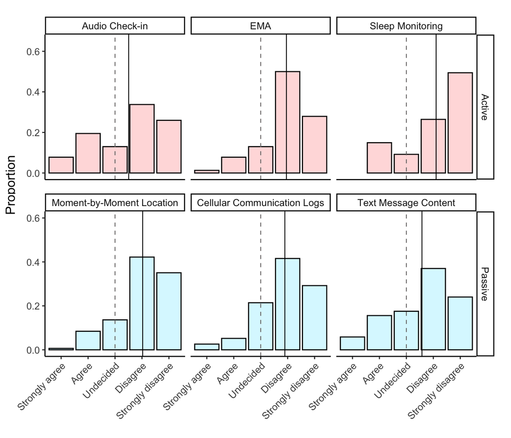

```r
burden_plot_dis <- burden_last %>%
  select(contains("dislike")) %>%
  pivot_longer(everything(), "measure", values_drop_na = TRUE) %>%
   mutate(measure = factor(measure,
                          levels = c("audio_checkin_dislike", "daily_survey_dislike", "sleep_dislike",
                                     "location_dislike", "all_logs_dislike", "sms_content_dislike"),
                          labels = c("Audio Check-in", "EMA", "Sleep Monitoring",
                                     "Moment-by-Moment Location", "Cellular Communication Logs", "Text Message Content"))) %>%
  mutate(value = factor(value, levels = c(-2:2), labels = c("Strongly agree", "Agree", "Undecided", "Disagree", "Strongly disagree"))) %>%
  mutate(active = case_when(measure == "Audio Check-in" ~ "Active",
                            measure == "EMA" ~ "Active",
                            measure == "Sleep Monitoring" ~ "Active",
                            measure == "Moment-by-Moment Location" ~ "Passive",
                            measure == "Cellular Communication Logs" ~ "Passive",
                            measure == "Text Message Content" ~ "Passive"))

active_dis <- burden_plot_dis %>%
  filter(measure == "Audio Check-in" | measure == "EMA" | measure == "Sleep Monitoring") %>%
  ggplot(aes(x = value, y = ..prop.., group = measure)) +
  geom_bar(color = "black", fill = "#FFDEDE") +
  facet_grid(active ~ measure) +
  theme_classic() +
  labs(y = NULL,
       x = NULL) +
  theme(legend.position = "none",
        axis.text.x=element_blank(),
        axis.ticks.x=element_blank(),
        text = element_text(family = "Arial", size = 12)) +
  ylim(0, .65) +
  geom_vline(aes(xintercept = means), burden_plot_dis %>%
  filter(measure == "Audio Check-in" | measure == "EMA" | measure == "Sleep Monitoring") %>%
  group_by(measure) %>%
  summarise(means = mean(as.numeric(value), na.rm = TRUE)), size = .4) +
  geom_vline(aes(xintercept = "Undecided"), linetype = "dashed", size = .4, color = "#787575") +
  theme(text = element_text(size = 12))


passive_dis <- burden_plot_dis %>%
  filter(measure == "Moment-by-Moment Location" | measure == "Cellular Communication Logs" | measure == "Text Message Content") %>%
  ggplot(aes(x = value, y = ..prop.., group = measure)) +
  geom_bar(color = "black", fill = "#DBF8FF") +
  facet_grid(active ~ measure) +
  theme_classic() +
  labs(y = NULL,
       x = NULL) +
    theme(legend.position = "none",
        text = element_text(family = "Arial", size = 12),
        axis.text.x = element_text(angle = 45, hjust = 1)) +
  ylim(0, .6) +
  geom_vline(aes(xintercept = means), burden_plot_dis %>%
  filter(measure == "Moment-by-Moment Location" | measure == "Cellular Communication Logs" | measure == "Text Message Content") %>%
  group_by(measure) %>%
  summarise(means = mean(as.numeric(value), na.rm = TRUE)), size = .4) +
  geom_vline(aes(xintercept = "Undecided"), linetype = "dashed", size = .4, color = "#787575")

dislike_final_plot <- wrap_plots(active_dis, passive_dis, ncol = 1)

dislike_final_plot <- dislike_final_plot  %>%
  add_global_label(Ylab = "                   Proportion",
                   Ygap = .02
)

dislike_final_plot
```

Save Figure

```r
# ggsave(plot = dislike_final_plot,  "~/Desktop/dislike.png", width = 7.75, height = 6, units = "in", device = "png",  dpi = 1000)
```

#### Willingness to Continue

```r
corrplot_will <- burden_last %>%
  select(`Audio Check-in` = audio_checkin_1year,
         `EMA` = daily_survey_4_1year,
         `Sleep Monitoring` = sleep_1year,
         `Moment-by-Moment Location` = location_1year,
         `Cellular Communication Logs` = all_logs_1year,
         `Text Message Content` = sms_content_1year) %>%
  corx(triangle = "lower",
       stars = c(0.05),
       method = "pearson",
       describe = c(`$M$` = mean, `$SD$` = sd))

corrplot_will <- as_tibble(corrplot_will, rownames = " ")
corrplot_will[corrplot_will== " - " ] <- "--"

corrplot_will <- corrplot_will %>%
  mutate(`$N$` = c(154, 154, 87, 154, 154, 154)) %>%
  mutate(`$t$` = c(str_c(round(use_a$statistic, 2), "*"),
                   str_c(round(use_s4$statistic, 2), "*"),
                   str_c(round(use_sl$statistic, 2), "*"),
                   str_c(round(use_loc$statistic, 2), "*"),
                   str_c(round(use_log$statistic, 2), "*"),
                   str_c(round(use_sms$statistic, 2), "*"))) %>%
  mutate(`$d$` = (c(round(use_a$d, 2), round(use_s4$d, 2), round(use_sl$d, 2),
                    round(use_loc$d, 2), round(use_log$d, 2), round(use_sms$d, 2)))) %>%
  select(` `, `1`, `2`, `3`, `4`, `5`, `$N$`, `$M$`, `$SD$`, everything())

corrplot_will %>%
  kbl(align = c("l", "c", "c", "c", "c", "c", "c", "c", "c", "c")) %>%
  kable_classic(html_font = "Arial") %>%
  pack_rows("Active", 1, 3, background = "#FFDEDE") %>%
  pack_rows("Passive", 4, 6, background = "#DBF8FF") %>%
  row_spec(c(1:3), background = "#FFDEDE") %>%
  row_spec(c(4:6), background = "#DBF8FF") %>%
  footnote("* p < 0.05")
```

1

2

3

4

5

$N$

$M$

$SD$

$t$

$d$

**Active**

1. Audio Check-in

–

154

0.73

1.28

7.09*

0.57

2. EMA

.44*

–

154

0.64

1.22

6.47*

0.52

3. Sleep Monitoring

.44*

.41*

–

87

0.85

1.28

6.19*

0.66

**Passive**

4. Moment-by-Moment Location

.51*

.48*

.53*

–

154

0.94

1.18

9.83*

0.79

5. Cellular Communication Logs

.47*

.47*

.47*

.65*

–

154

0.84

1.07

9.76*

0.79

6. Text Message Content

.47*

.39*

.37*

.60*

.84*

154

0.74

1.12

8.21*

0.66

Note:

* p < 0.05

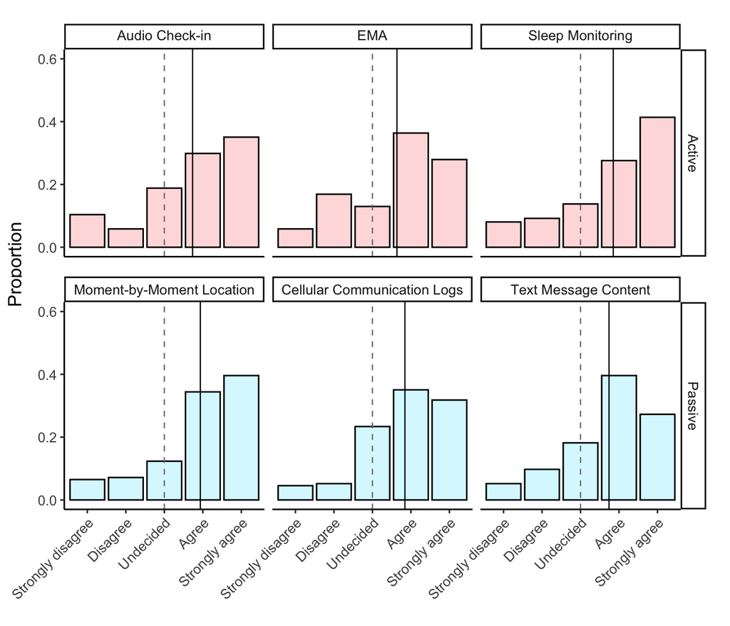

```r
burden_plot_1yr <- burden_last %>%
  select(contains("1year")) %>%
  pivot_longer(everything(), "measure", values_drop_na = TRUE) %>%
  mutate(measure = factor(measure,
                          levels = c("audio_checkin_1year", "daily_survey_4_1year",
                                     "daily_survey_1_1year", "sleep_1year", "location_1year",
                                     "all_logs_1year", "sms_content_1year"),
                          labels = c("Audio Check-in", "EMA", "Daily Survey (x1)<i><sup>a</sup></i>",
                                     "Sleep Monitoring", "Moment-by-Moment Location", "Cellular Communication Logs", "Text Message Content"))) %>%
  mutate(value = factor(value, levels = c(-2:2), labels = c("Strongly disagree", "Disagree", "Undecided", "Agree", "Strongly agree"))) %>%
  mutate(active = case_when(measure == "Audio Check-in" ~ "Active",
                            measure == "EMA" ~ "Active",
                            measure == "Sleep Monitoring" ~ "Active",
                            measure == "Moment-by-Moment Location" ~ "Passive",
                            measure == "Cellular Communication Logs" ~ "Passive",
                            measure == "Text Message Content" ~ "Passive"))

willingness_active <- burden_plot_1yr %>%
  filter(measure == "Audio Check-in" | measure == "EMA" | measure == "Sleep Monitoring") %>%
  ggplot(aes(x = value, y = ..prop.., group = measure)) +
  geom_bar(color = "black", fill = "#FFDEDE") +
  facet_grid(active ~ measure) +
  theme_classic() +
  labs(y = NULL,
       x = NULL) +
  theme(legend.position = "none",
        axis.text.x=element_blank(),
        axis.ticks.x=element_blank(),
        text = element_text(family = "Arial", size = 12),
        strip.text = element_markdown()) +
  ylim(0, .6) +
  geom_vline(aes(xintercept = means), burden_plot_1yr %>%
  filter(measure == "Audio Check-in" | measure == "EMA" | measure == "Sleep Monitoring") %>%
  group_by(measure) %>%
  summarise(means = mean(as.numeric(value), na.rm = TRUE)), size = .4) +
  geom_vline(aes(xintercept = "Undecided"), linetype = "dashed", size = .4, color = "#787575")


willingness_passive <- burden_plot_1yr %>%
  filter(measure == "Moment-by-Moment Location" | measure == "Cellular Communication Logs" | measure == "Text Message Content") %>%
  ggplot(aes(x = value, y = ..prop.., group = measure)) +
  geom_bar(color = "black", fill = "#DBF8FF") +
  facet_grid(active ~ measure) +
  theme_classic() +
  labs(y = NULL,
       x = NULL) +
    theme(legend.position = "none",
        text = element_text(family = "Arial", size = 12),
        axis.text.x = element_text(angle = 45, hjust = 1)) +
  ylim(0, .6) +
  geom_vline(aes(xintercept = means), burden_plot_1yr %>%
  filter(measure == "Moment-by-Moment Location" | measure == "Cellular Communication Logs" | measure == "Text Message Content") %>%
  group_by(measure) %>%
  summarise(means = mean(as.numeric(value), na.rm = TRUE)), size = .4) +
  geom_vline(aes(xintercept = "Undecided"), linetype = "dashed", size = .4, color = "#787575")

willingness_final_plot <- wrap_plots(willingness_active, willingness_passive, ncol = 1)

willingness_final_plot <- willingness_final_plot  %>%
  add_global_label(Ylab = "                   Proportion",
                   Ygap = .02
)

willingness_final_plot
```

Save Figure

```r
# ggsave(plot = willingness_final_plot,  "~/Desktop/willingness.png", width = 7.75, height = 6, units = "in", device = "png",  dpi = 1000)
```

### ICC

**Interested in type = ICC3**

#### Interference

```r
burden_last %>%
  select(`Daily survey` = daily_survey_interfere,
         `Audio check-in` = audio_checkin_interfere) %>%
  ICC()
```

```
## Call: ICC(x = .)
##
## Intraclass correlation coefficients
##                          type  ICC   F df1 df2       p lower bound upper bound
## Single_raters_absolute   ICC1 0.42 2.5 153 154 2.3e-08        0.31        0.52
## Single_random_raters     ICC2 0.42 2.5 153 153 2.0e-08        0.31        0.52
## Single_fixed_raters      ICC3 0.42 2.5 153 153 2.0e-08        0.31        0.53
## Average_raters_absolute ICC1k 0.59 2.5 153 154 2.3e-08        0.47        0.69
## Average_random_raters   ICC2k 0.59 2.5 153 153 2.0e-08        0.47        0.69
## Average_fixed_raters    ICC3k 0.60 2.5 153 153 2.0e-08        0.47        0.69
##
##  Number of subjects = 154     Number of Judges =  2
```

#### Dislike

```r
burden_last %>%
  select(`Daily survey` = daily_survey_dislike,
         `Audio check-in` = audio_checkin_dislike,
         `Location` = location_dislike,
         `Logs (SMS/voice)` = all_logs_dislike,
         `SMS content` = sms_content_dislike) %>%
  ICC()
```

```
## Call: ICC(x = .)
##
## Intraclass correlation coefficients
##                          type  ICC   F df1 df2       p lower bound upper bound
## Single_raters_absolute   ICC1 0.39 4.2 153 616 1.7e-37        0.33        0.46
## Single_random_raters     ICC2 0.40 4.6 153 612 2.2e-41        0.33        0.47
## Single_fixed_raters      ICC3 0.42 4.6 153 612 2.2e-41        0.35        0.48
## Average_raters_absolute ICC1k 0.76 4.2 153 616 1.7e-37        0.71        0.81
## Average_random_raters   ICC2k 0.77 4.6 153 612 2.2e-41        0.71        0.81
## Average_fixed_raters    ICC3k 0.78 4.6 153 612 2.2e-41        0.73        0.82
##
##  Number of subjects = 154     Number of Judges =  5
```

#### Willingness

```r
burden_last %>%
  select(`Daily survey` = daily_survey_4_1year,
         `Audio check-in` = audio_checkin_1year,
         `Location` = location_1year,
         `Logs (SMS/voice)` = all_logs_1year,
         `SMS content` = sms_content_1year) %>%
  ICC()
```

```
## Call: ICC(x = .)
##
## Intraclass correlation coefficients
##                          type  ICC   F df1 df2       p lower bound upper bound
## Single_raters_absolute   ICC1 0.52 6.4 153 616 2.2e-62        0.46        0.58
## Single_random_raters     ICC2 0.52 6.5 153 612 4.0e-63        0.46        0.58
## Single_fixed_raters      ICC3 0.52 6.5 153 612 4.0e-63        0.46        0.58
## Average_raters_absolute ICC1k 0.84 6.4 153 616 2.2e-62        0.81        0.87
## Average_random_raters   ICC2k 0.84 6.5 153 612 4.0e-63        0.81        0.87
## Average_fixed_raters    ICC3k 0.85 6.5 153 612 4.0e-63        0.81        0.88
##
##  Number of subjects = 154     Number of Judges =  5
```